# Mo_Wentao_hw5

# We can state more interesting findings here. Why the payroll data for NYA(New York Yankees) experienced a small fluctuations from 2012-2014? From the dataset provided online:

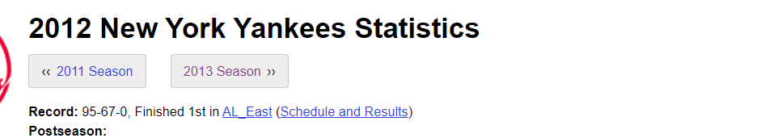

```python
# Reference:  https://www.baseball-reference.com/teams/NYY/2012.shtml
Image("NYA_2012.png") # We insert the image.
```

[figure not shown]

```python
# Reference:  https://www.baseball-reference.com/teams/NYY/2013.shtml
Image("NYA_2013.png") # We insert the image.
```

[figure not shown]

```python
# Reference:  https://www.baseball-reference.com/teams/NYY/2014.shtml
Image("NYA_2014.png") # We insert the image.
```

# We find that they experienced some fluctuations for their rank in the American League East Competition might have some effections on their payrolls.

# Questions Four: How do the top 5 teams compare to other teams?

# We can do an analysis which we can extract out all some high-income players, and see what kind of result we will get:

```python
# For the first line here, we select the salary for specific player,their corresponding teamID, and year ID from the Salaries database
# For the second line here, we specify the condition: Let the year Between 2006 and 2016.
# For the third line here, we order our result from the largest payroll to the smallest payroll.

import pandas as pd # Import the required package
dataset1 = pd.read_sql("""
SELECT playerID , teamID, yearID, salary FROM salaries
WHERE yearID BETWEEN 2006 AND 2016
ORDER BY salary DESC
""", db).head(20)
dataset1
```

|  | playerID | teamID | yearID | salary |
| --- | --- | --- | --- | --- |
| 0 | rodrial01 | NYA | 2009 | 33000000.0 |
| 1 | rodrial01 | NYA | 2010 | 33000000.0 |
| 2 | kershcl01 | LAN | 2016 | 33000000.0 |
| 3 | kershcl01 | LAN | 2015 | 32571000.0 |
| 4 | rodrial01 | NYA | 2011 | 32000000.0 |
| 5 | greinza01 | ARI | 2016 | 31799030.0 |
| 6 | rodrial01 | NYA | 2012 | 30000000.0 |
| 7 | priceda01 | BOS | 2016 | 30000000.0 |
| 8 | rodrial01 | NYA | 2013 | 29000000.0 |
| 9 | rodrial01 | NYA | 2008 | 28000000.0 |
| 10 | verlaju01 | DET | 2015 | 28000000.0 |
| 11 | cabremi01 | DET | 2016 | 28000000.0 |
| 12 | verlaju01 | DET | 2016 | 28000000.0 |
| 13 | cespeyo01 | NYN | 2016 | 27328046.0 |
| 14 | wellsve01 | LAA | 2011 | 26187500.0 |
| 15 | greinza01 | LAN | 2014 | 26000000.0 |
| 16 | hernafe02 | SEA | 2016 | 25857143.0 |
| 17 | leecl02 | PHI | 2013 | 25000000.0 |
| 18 | howarry01 | PHI | 2014 | 25000000.0 |
| 19 | leecl02 | PHI | 2014 | 25000000.0 |

# If we display the top twenty highest paid players, we can find that most of them is in our top 5 team, and we can extract out the corresponding data to calculate the actual percentage:

```python
team_id_20 = dataset1["teamID"] # Extract the list for the team id, which 20 highest paid players belong to
lst = team_id_20.tolist() # And we can convert it to list.
lst # Output the list
```

```
['NYA',
 'NYA',
 'LAN',
 'LAN',
 'NYA',
 'ARI',
 'NYA',
 'BOS',
 'NYA',
 'NYA',
 'DET',
 'DET',
 'DET',
 'NYN',
 'LAA',
 'LAN',
 'SEA',
 'PHI',
 'PHI',
 'PHI']
```

```python
top_5_list = ["NYA", "LAN", "BOS", "DET", "PHI"]
print("The list which contatin the top_5_team elements", [w for w in lst if w in top_5_list]) # Print the list
print("The length of the list which contatin the top_5_team elements", len([w for w in lst if w in top_5_list])) #Print the length
print("The percentage of the top 20 paid players in top_5_payroll team", len([w for w in lst if w in top_5_list])/len(lst)*100)
                                                                        # Print out the percentage.
```

```
The list which contatin the top_5_team elements ['NYA', 'NYA', 'LAN', 'LAN', 'NYA', 'NYA', 'BOS', 'NYA', 'NYA', 'DET', 'DET', 'DET', 'LAN', 'PHI', 'PHI', 'PHI']
The length of the list which contatin the top_5_team elements 16
The percentage of the top 20 paid players in top_5_payroll team 80.0
```

# What about top 10 paid players?

```python
# For the first line here, we select the salary for specific player,their corresponding teamID, and year ID from the Salaries database
# For the second line here, we specify the condition: Let the year Between 2006 and 2016.
# For the third line here, we order our result from the largest payroll to the smallest payroll.

import pandas as pd # Import the required package
dataset3 = pd.read_sql("""
SELECT playerID , teamID, yearID, salary FROM salaries
WHERE yearID BETWEEN 2006 AND 2016
ORDER BY salary DESC
""", db).head(10)
dataset3
```

|  | playerID | teamID | yearID | salary |
| --- | --- | --- | --- | --- |
| 0 | rodrial01 | NYA | 2009 | 33000000.0 |
| 1 | rodrial01 | NYA | 2010 | 33000000.0 |
| 2 | kershcl01 | LAN | 2016 | 33000000.0 |
| 3 | kershcl01 | LAN | 2015 | 32571000.0 |
| 4 | rodrial01 | NYA | 2011 | 32000000.0 |
| 5 | greinza01 | ARI | 2016 | 31799030.0 |
| 6 | rodrial01 | NYA | 2012 | 30000000.0 |
| 7 | priceda01 | BOS | 2016 | 30000000.0 |
| 8 | rodrial01 | NYA | 2013 | 29000000.0 |
| 9 | rodrial01 | NYA | 2008 | 28000000.0 |

```python
lst_10 = dataset3["teamID"].tolist() # Extract the list for the team id, which 20 highest paid players belong to

top_5_list = ["NYA", "LAN", "BOS", "DET", "PHI"] # Top five team list.
print("The list which contatin the top_5_team elements", [w for w in lst_10 if w in top_5_list]) # Print the list
print("The length of the list which contatin the top_5_team elements", len([w for w in lst_10 if w in top_5_list])) #Print the length
print("The percentage of the top 20 paid players in top_5_payroll team", len([w for w in lst_10 if w in top_5_list])/len(lst_10)*100)
                                                                        # Print out the percentage.
```

```
The list which contatin the top_5_team elements ['NYA', 'NYA', 'LAN', 'LAN', 'NYA', 'NYA', 'BOS', 'NYA', 'NYA']
The length of the list which contatin the top_5_team elements 9
The percentage of the top 20 paid players in top_5_payroll team 90.0
```

# What about top 50 paid players?

```python
# For the first line here, we select the salary for specific player,their corresponding teamID, and year ID from the Salaries database
# For the second line here, we specify the condition: Let the year Between 2006 and 2016.
# For the third line here, we order our result from the largest payroll to the smallest payroll.

import pandas as pd # Import the required package
dataset2 = pd.read_sql("""
SELECT playerID , teamID, yearID, salary FROM salaries
WHERE yearID BETWEEN 2006 AND 2016
ORDER BY salary DESC
""", db).head(50)
dataset2
```

|  | playerID | teamID | yearID | salary |
| --- | --- | --- | --- | --- |
| 0 | rodrial01 | NYA | 2009 | 33000000.0 |
| 1 | rodrial01 | NYA | 2010 | 33000000.0 |
| 2 | kershcl01 | LAN | 2016 | 33000000.0 |
| 3 | kershcl01 | LAN | 2015 | 32571000.0 |
| 4 | rodrial01 | NYA | 2011 | 32000000.0 |
| 5 | greinza01 | ARI | 2016 | 31799030.0 |
| 6 | rodrial01 | NYA | 2012 | 30000000.0 |
| 7 | priceda01 | BOS | 2016 | 30000000.0 |
| 8 | rodrial01 | NYA | 2013 | 29000000.0 |
| 9 | rodrial01 | NYA | 2008 | 28000000.0 |
| 10 | verlaju01 | DET | 2015 | 28000000.0 |
| 11 | cabremi01 | DET | 2016 | 28000000.0 |
| 12 | verlaju01 | DET | 2016 | 28000000.0 |
| 13 | cespeyo01 | NYN | 2016 | 27328046.0 |
| 14 | wellsve01 | LAA | 2011 | 26187500.0 |
| 15 | greinza01 | LAN | 2014 | 26000000.0 |
| 16 | hernafe02 | SEA | 2016 | 25857143.0 |
| 17 | leecl02 | PHI | 2013 | 25000000.0 |
| 18 | howarry01 | PHI | 2014 | 25000000.0 |
| 19 | leecl02 | PHI | 2014 | 25000000.0 |
| 20 | greinza01 | LAN | 2015 | 25000000.0 |
| 21 | howarry01 | PHI | 2015 | 25000000.0 |
| 22 | lestejo01 | CHN | 2016 | 25000000.0 |
| 23 | pujolal01 | LAA | 2016 | 25000000.0 |
| 24 | sabatcc01 | NYA | 2016 | 25000000.0 |
| 25 | hernafe02 | SEA | 2015 | 24857000.0 |
| 26 | wellsve01 | NYA | 2013 | 24642857.0 |
| 27 | sabatcc01 | NYA | 2010 | 24285714.0 |
| 28 | sabatcc01 | NYA | 2011 | 24285714.0 |
| 29 | sabatcc01 | NYA | 2013 | 24285714.0 |
| 30 | wellsve01 | LAA | 2012 | 24187500.0 |
| 31 | canoro01 | SEA | 2014 | 24000000.0 |
| 32 | fieldpr01 | TEX | 2014 | 24000000.0 |
| 33 | pujolal01 | LAA | 2015 | 24000000.0 |
| 34 | canoro01 | SEA | 2015 | 24000000.0 |
| 35 | fieldpr01 | TEX | 2015 | 24000000.0 |
| 36 | canoro01 | SEA | 2016 | 24000000.0 |
| 37 | fieldpr01 | TEX | 2016 | 24000000.0 |
| 38 | hamiljo03 | TEX | 2016 | 24000000.0 |
| 39 | ramirma02 | LAN | 2009 | 23854494.0 |
| 40 | hamelco01 | PHI | 2015 | 23500000.0 |
| 41 | giambja01 | NYA | 2007 | 23428571.0 |
| 42 | giambja01 | NYA | 2008 | 23428571.0 |
| 43 | santajo01 | NYN | 2012 | 23145011.0 |
| 44 | teixema01 | NYA | 2011 | 23125000.0 |
| 45 | teixema01 | NYA | 2012 | 23125000.0 |
| 46 | teixema01 | NYA | 2013 | 23125000.0 |
| 47 | teixema01 | NYA | 2015 | 23125000.0 |
| 48 | teixema01 | NYA | 2016 | 23125000.0 |
| 49 | mauerjo01 | MIN | 2011 | 23000000.0 |

```python
lst_50 = dataset2["teamID"].tolist() # Extract the list for the team id, which 20 highest paid players belong to

top_5_list = ["NYA", "LAN", "BOS", "DET", "PHI"] # Top five team list.
print("The list which contatin the top_5_team elements", [w for w in lst_50 if w in top_5_list]) # Print the list
print("The length of the list which contatin the top_5_team elements", len([w for w in lst_50 if w in top_5_list])) #Print the length
print("The percentage of the top 20 paid players in top_5_payroll team", len([w for w in lst_50 if w in top_5_list])/len(lst_50)*100)
                                                                        # Print out the percentage.
```

```
The list which contatin the top_5_team elements ['NYA', 'NYA', 'LAN', 'LAN', 'NYA', 'NYA', 'BOS', 'NYA', 'NYA', 'DET', 'DET', 'DET', 'LAN', 'PHI', 'PHI', 'PHI', 'LAN', 'PHI', 'NYA', 'NYA', 'NYA', 'NYA', 'NYA', 'LAN', 'PHI', 'NYA', 'NYA', 'NYA', 'NYA', 'NYA', 'NYA', 'NYA']
The length of the list which contatin the top_5_team elements 32
The percentage of the top 20 paid players in top_5_payroll team 64.0
```

# From the above evaluation, we can mainly conclude that: top paid players are mostly in the team which receive the top 5 highest payroll, and we can see that even though the percentage is decreasing if we increase the number we use to evaluate the top paid players, earnings of high-paid players remain an important salary component for top-five payroll team.